# Reproducible Research: Peer Assessment 1

This report serves the purpose of Peer Assignment 1 for course Reproducible Research. Assignment questions are answered under different part of this report below. This is generated by Knitr using R markdown document.

#### Loading and Preprocessing Data

##### 1. Loading the data

Loading data from activity.csv file.

```r
actdata <- read.csv(unz("activity.zip", "activity.csv"),header=TRUE,na.strings="NA",stringsAsFactors=FALSE,skipNul=TRUE,colClasses=c("numeric","Date","numeric"))
```

##### 2. Preprocess/Transform data

```r
dayttl <- tapply(actdata$steps,actdata$date,sum,na.rm=TRUE)
```

#### What is mean total number of steps taken per day?

##### 1. Histogram of total number of steps taken each day

Histogram of total number of steps taken each day

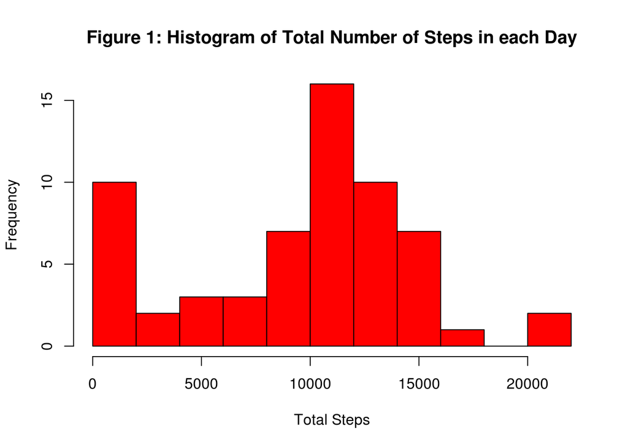

```r
hist(dayttl, breaks=10, col="red", main="Figure 1: Histogram of Total Number of Steps in each Day", xlab="Total Steps")
```

##### 2. Calculation and report of mean and median total number of steps taken per day

Calculating mean and median

```r
mean(dayttl)
```

```
## [1] 9354.23
```

```r
median(dayttl)
```

```
## [1] 10395
```

#### What is the average daily activity pattern?

##### 1. Time series plot of the 5-minute interval (x-axis) and average number of steps taken, averaged across all days (y-axis)

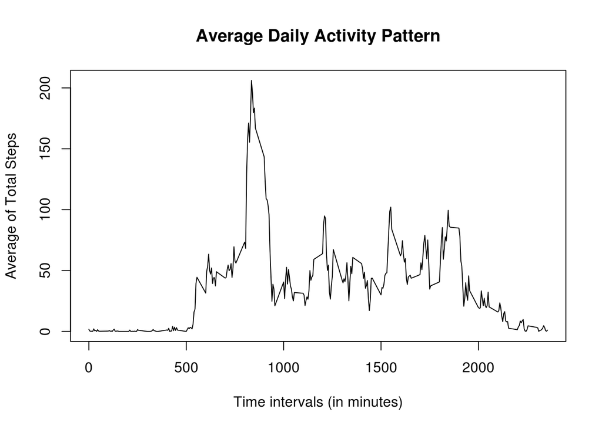

```r
mean_by_int <- tapply(actdata$steps,actdata$interval,mean,na.rm=TRUE)
plot(row.names(mean_by_int),mean_by_int,type="l",xlab="Time intervals (in minutes)",ylab="Average of Total Steps",main="Average Daily Activity Pattern")
```

##### 2. 5-minute interval, on average across all the days in the dataset, containing the maximum number of steps

```r
x <- max(mean_by_int)
match(x,mean_by_int)
```

```
## [1] 104
```

```r
mean_by_int[104]
```

```
##      835
## 206.1698
```

#### Imputing missing values

##### 1. Calculate and report the total numbre of missing values in the dataset (1.e. the total number of rows with NAs)

```r
sum(is.na(actdata))
```

```
## [1] 2304
```

##### 2. Devise a strategy for filling in all of the missing values in the dataset. The strategy does not need to be sophisticated. For example, you could use the mean/median for that day, or the mean for that 5-minute interval, etc.

```r
act_na <- actdata[is.na(actdata),]
act_no_na <- actdata[complete.cases(actdata),]
act_na$steps <- as.numeric(mean_by_int)
```

##### 3. Create a new dataset that is equal to the original dataset but with the missing data filled in.

```r
new_act <- rbind(act_na,act_no_na)
new_act <- new_act[order(new_act[,2],new_act[,3]),]
```

##### 4. Make a histogram of the total number of steps taken each day and Calculate and report the mean and median total number of steps taken per day. Do these values differ from the estimates from the first part of the assignment? What is the impact of imputing missing data on the estimates of the total daily number of steps?

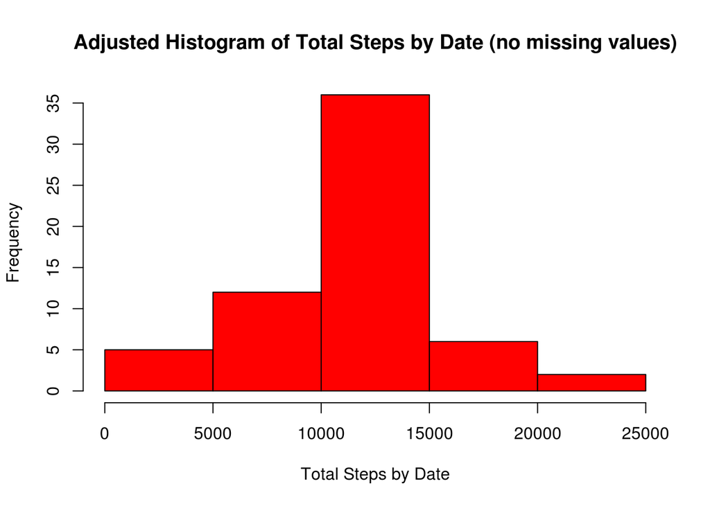

```r
new_sum_by_date <- tapply(new_act$steps,new_act$date,sum)
hist(new_sum_by_date,col="red",xlab="Total Steps by Date",main="Adjusted Histogram of Total Steps by Date (no missing values)")
```

```r
mean(new_sum_by_date)
```

```
## [1] 10766.19
```

```r
median(new_sum_by_date)
```

```
## [1] 10766.19
```

#### Are there differences in activity patterns between weekdays and weekends?

##### 1. Create a new factor variable in the dataset with two levels – “weekday” and “weekend” indicating whether a given date is a weekday or weekend day.

```r
days <- weekdays(new_act[,2])
new_act <- cbind(new_act,days)

library(plyr)
new_act$days <- revalue(new_act$days,c("Monday"="weekday","Tuesday"="weekday","Wednesday"="weekday","Thursday"="weekday","Friday"="weekday"))
new_act$days <- revalue(new_act$days,c("Saturday"="weekend","Sunday"="weekend"))
new_mean_by_int <- tapply(new_act$steps,list(new_act$interval,new_act$days),mean)

library(reshape2)
new_mean_by_int <- melt(new_mean_by_int)
colnames(new_mean_by_int) <- c("interval","day","steps")
```

##### 2. Make a panel plot containing a time series plot (i.e. type = “l”) of the 5-minute interval (x-axis) and the average number of steps taken, averaged across all weekday days or weekend days (y-axis)

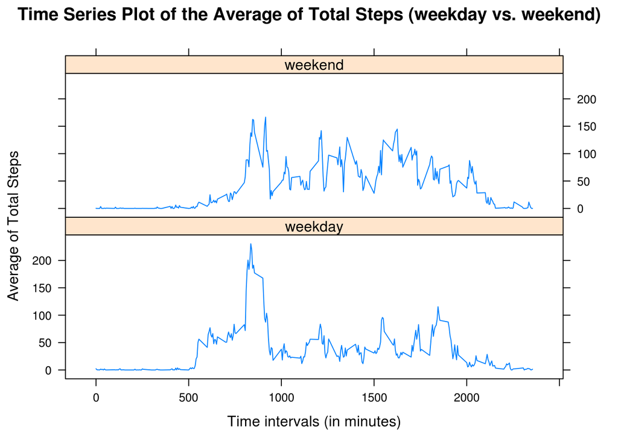

```r
library(lattice)
xyplot(new_mean_by_int$steps ~ new_mean_by_int$interval | new_mean_by_int$day, layout=c(1,2),type="l",main="Time Series Plot of the Average of Total Steps (weekday vs. weekend)",xlab="Time intervals (in minutes)",ylab="Average of Total Steps")
```